# homework

20031

2020/12/14

## Exsample 2

### R Syntax and Commonly Used Operators

| Description | R symbol | Example |
| --- | --- | --- |
| Comment | # | #this is a comment |
| Assignment | <- | x <- log2(2) |
| Concatenation operator | c | c(3,2,2) |
| Elementwise multiplication | * | a * b |
| Exponentiation | ^ | 2^1.5 |
| x mod y | x %% y | 25 %% 3 |
| Integer division | %/% | 25 %/% 3 |
| Sequence from a to b by h | seq | seq(a,b,h) |
| Sequence | : | 0:20 |

## Exsample 3

### Geometric Distribution

The Pareto(a,b) distribution has cdf $F(x)=1-(\frac{b}{x})^a,x\geq b>0,a>0$.

1. Derive $F^{-1}(U)$.
2. Use the inverse transform method to simulate a random sample from Pareto(2,2) distribution.Graph the density histogram of the sample with the Pareto(2, 2) density superimposed for comparison.

## Answer

1. let U $\sim$ (0,1),then
   $$U=F(X)=1-(\frac{b}{X})^a \Longleftrightarrow (\frac{b}{X})^a=1-U \Longleftrightarrow X=\frac{b}{(1-U)^{\frac{1}{a}}}$$
   and $F^{-1}(U)=X$,so
   $$F^{-1}(U)=\frac{b}{(1-U)^{\frac{1}{a}}}$$

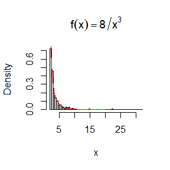

```r
set.seed(1)

n <- 500
u <- runif(n)
x <- 2/sqrt(1-u) # Pareto(2,2) random numbers

# Graph the density histogram of the sample
hist(x, prob = TRUE, breaks = 50, main = expression(f(x) == 8/x^3))

# superimpose the Pareto(2,2) density function curve
y <- seq(2,20, 0.1)
lines(y, 8/y^3, col = 'red')
```

## Question

For a density function $f_e(x)=\frac{3}{4}(1-x^2),|x|\leq 1$,there is an algorithm for simulation:Generate iid $U_1,U_2,U_3\sim$ Uniform(-1,1).If $|U_3|\geq |U_2|$ and $|U_3|\geq |U_1|$,deliver $U_2$; otherwise deliver $U_3$.Write a function to generate random variates from $f_e$, and construct the histogram density estimate of a large simulated random sample.

## Answer

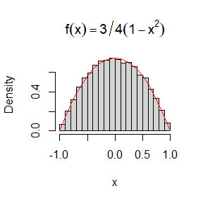

```r
n <- 10000
# generate three iid uniform distribution random number
u1 <- runif(n, min = -1, max = 1)
u2 <- runif(n, min = -1, max = 1)
u3 <- runif(n, min = -1, max = 1)

x <- seq(1:n) # initialize
# use the algorithm to generate variates from fe
for(i in 1:n)
{
  if((abs(u3[i]) >= abs(u2[i]))&(abs(u3[i]) >= abs(u1[i])))
    {x[i] <- u2[i]}
  else
    {x[i] <- u3[i]}
}

# construct the histogram
hist(x, probability = TRUE, main = expression(f(x)==3/4 * (1-x^2)))

# superimpose the density function curve
y <- seq(-1, 1, 0.1)
lines(y, 3/4 * (1 - y^2), col = 'red')
```

## Question

Prove that the algorithm given in previous Exercise generates variates from the density $f_e$.

## Answer

suppose
$$Y = \left. \Big\{ \begin{array}{ll}
U_2 & \textrm{if |$U_3$|$\geq$ |$U_1$| and |$U_3$|$\geq$ |$U_2$|}\\
U_3 & \textrm{otherwise}\end{array} \right.$$
$U_1,U_2,U_3$ iid, use their symmetry simultaneously,we have
$$\begin{align}
P(Y\leq y)&=P(U_2 \leq y,|U_1|\leq |U_2|\leq |U_3|)+P(U_2 \leq y,|U_2|\leq|U_1|\leq|U_3)\\
\\
&\quad +2P(U_3,|U_1|\leq |U_3|\leq |U_2|)+2P(U_3\leq y,|U_3|\leq |U_2|\leq |U_1|)\\
\\
&=3P(U_2 \leq y,|U_1|\leq |U_2|\leq |U_3|)+3P(U_1\leq y,|U_1|\leq |U_2|\leq |U_3|)\\
\\
&=\frac{3}{8} \int_{-1}^{y} d u_2 \int_{|u_2|}^{1} 2 d u_3 \int_{0}^{|u_2|} 2 d u_1 + \frac{3}{8} \int_{-1}^{y} d u_1 \int_{|u_1|}^{1} 2 d u_2 \int_{|u_2|}^{1} 2 d u_3\\
\\
&=\frac{3}{2}\int_{-1}^{y}(|u_2|-u_2 ^ 2)du_2 + \frac{3}{2}\int_{-1}^{y}(\frac{1-2|u_1| + u_1 ^2}{2})du_1
\end{align}$$
let F(y),f(y) be cdf and pdf of Y respectively,then
$$f(y)=F(y)^{'}=\frac{3}{4}(1-y^2)$$

## Qusetion

Suppose $\Lambda$ has Gamma(r,$\beta$) distribution and Y has Exp($\Lambda$) distribution. Then the mixture has a Pareto distribution with cdf $F(y) = 1 - (\frac{\beta}{\beta + y})^r,y\geq 0$.Generate 1000 random observations from the mixture with r = 4 and $\beta$ = 2. Compare the empirical and theoretical (Pareto) distributions by graphing the density histogram of the sample and superimposing the Pareto density curve.

## Answer

[figure not shown]

```r
set.seed(1)

# generate random observations
n <- 1000
g <- rgamma(n, shape = 4, rate = 2)
y <- rexp(n,rate = g)

# graph the density histogram of the sample
hist(y, probability = TRUE, main = expression(f(y)==64/(1+y)^5), breaks = 50)

#superimpose the Pareto density curve
x <- seq(0, 5, 0.1)
lines(x, 64/(2 + x)^5, col = 'red')
```

## Exercise 5.1

Compute a Monte Carlo estimate of
$$\int_0^{\pi/3}\sin{t}\,dt$$
and compare your estimate with the exact value of the integral.

### answer

```r
set.seed(123)

n <- 1e4
u <- runif(n, min = 0, max = pi/3)
theta.hat <- mean(sin(u)) * pi / 3 # estimated value
theta = cos(0) - cos(pi / 3) # exact value
print(c(theta, theta.hat))
```

```
## [1] 0.50000 0.49808
```

## Exercise 5.7

$$\theta = \int_0^1 e^x\,dx$$
Use a Monte Carlo simulation to estimate $\theta$ by the antithetic variate approach and by the simple Monte Carlo method. Compute an empirical estimate of the percent reduction in variance using the antithetic variate. Compare the result with the theoretical value.

### answer

Suppose n is sample size, $\hat{\theta}$ is estimated value,$\hat{\theta ^{'}}$ is theoretical value,then
$$\hat{\theta} = \frac{\sum\limits_{i=1}^{n}e^{U_i}}{n},\qquad U_i \sim U(0,1)$$
$$\hat{\theta ^{'}}=\frac{\sum\limits_{i=1}^{n/2}(e^{U_i}+e^{1-U_i})}{n}, \qquad U_i \sim U(0,1)$$
$$Var(e^U)=E(e^{2U})-(E(e^U))^2=2e-\frac{e^2+3}{2}$$
$$Var(e^U+e^{1-U})=2Var(e^U)+2Cov(e^U,e^{1-U})=10e-3e^2-5$$
$$Var(\hat{\theta})=\frac{Var(e^U)}{n}=\frac{4e-e^2-3}{2n}$$
$$Vra(\hat{\theta ^{'}})=\frac{Var(e^U+e^{1-U})}{2n}=\frac{10e-3e^2-5}{2n}$$

```r
set.seed(1234)
n <- 1e4

# MC method function
MC <- function(number, antithetic) {
  u <- runif(number/2)
  if (!antithetic) v <- runif(number/2) else v <- 1 - u
  u <- c(u, v)
  population <- seq(1, number, 1)
  for (i in 1:number) {
    population[i] <- exp(u[i])
  }
  mean(population)
}

# function to compute empirical variance
variance <- function(Antithetic = FALSE){
  N <- 1e4
  population <- seq(1, N, 1)
  for (i in 1:length(population)){
    population[i] <- MC(n, antithetic = Antithetic)
  }
  var(population)
}

# estimate theta with the simple Monte Carlo method
theta.hat1 <- MC(n, antithetic = FALSE)

# estimate theta with the antithetic variate method
theta.hat2 <- MC(n, antithetic = TRUE)

# estimate variance of theta with the simple Monte Carlo method
theta.hat1.variance <- variance()

# estimate variance of theta with the antithetic variate method
theta.hat2.variance <- variance(Antithetic = TRUE)

e <- exp(1)
reduction <- (10*e-3*e^2-5)/(4*e-e^2-3) # theoretical the percent reduction value
reduction.hat <- theta.hat2.variance/theta.hat1.variance # empirical the percent reduction value
print(c(reduction,reduction.hat))
```

```
## [1] 0.03232993 0.03315714
```

## Exercise 5.11

If $\hat{\theta}_1$ and $\hat{\theta}_2$ are unbiased estimators of $\theta$, and $\hat{\theta}_1$ and $\hat{\theta}_2$ are antithetic, we derived that $c^{\ast}= 1/2$ is the optimal constant that minimizes the variance of $\hat{\theta}_c = c\hat{\theta}_1+(1-c)\hat{\theta}_2$.Derive $c^{\ast}$ for the general case.That is, if $\hat{\theta}_1$ and $\hat{\theta}_2$ are any two unbiased estimators of $\theta$, find the value $c^{\ast}$ that minimizes the variance of the estimators $\hat{\theta}_c=c\hat{\theta}_1+(1-c)\hat{\theta}_2$.

### answer

The variance of $c^{\ast}$ is
$$Var(\hat{\theta}_2)+c^2Var(\hat{\theta}_1-\hat{\theta}_2)+2cCov(\hat{\theta}_2,\hat{\theta}_1-\hat{\theta}_2)$$
Obviously, question is meaningless when $Var(\hat{\theta}_1-\hat{\theta}_2)=0$,suppose$Var(\hat{\theta}_1-\hat{\theta}_2)>0$,then
$$Var(c^{\ast})=Var(\hat{\theta}_2)+(c\sqrt{Var(\hat{\theta}_1-\hat{\theta}_2)}+\frac{Cov(\hat{\theta}_2,\hat{\theta}_1-\hat{\theta}_2)}{\sqrt{Var(\hat{\theta}_1-\hat{\theta}_2)}})^2-C,\qquad C\,is\, constant$$
so when $c=-\frac{Cov(\hat{\theta}_2,\hat{\theta}_1-\hat{\theta}_2)}{Var(\hat{\theta}_1-\hat{\theta}_2)}$,$Var\hat{\theta}^{\ast}$ is minimum.

## Exercise 5.13

Find two importance functions $f_1$ and $f_2$ that are supposed on $(1,\infty)$ and are ‘close’ to
$$g(x)=\frac{x^2}{\sqrt{2\pi}}e^{-x^2/2}dx,\qquad x>1.$$
Which of your two importance functions should produce the smaller variance in estimating
$$\int_1^{\infty}\frac{x^2}{\sqrt{2\pi}}e^{-x^2/2}$$
by importance sampling?Explain.

## Answer

$$f_1(x)=\frac{1}{\sqrt{2\pi}}e^{-(x-1)^2/2}I(x\geq 1)$$
$$f_2(x)=\frac{e^{-x/2}}{\sqrt{2\pi}}I(x\geq1)$$

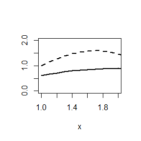

```r
x <- seq(1,10,0.1)
w <- 2
f <- x^2*exp(-x^2/2)/(sqrt(2*pi))
f1 <- exp(-(x-1)^2/2)/(sqrt(2*pi))
f2 <- exp(-x/2)/(sqrt(2*pi))

plot(x, f/f1, type = 'l', main = '', ylab = '', lwd = w,ylim = c(0,2), xlim = c(1,2))
lines(x, f/f2, lty = 2, lwd = w)
```

$f_1,f_2$ is easy to generate, $f_1$ is closer f, so $f_1$ will produce the smaller variance in estimating.

## Exercise 5.15

Obtain the stratified importance sampling estimate in Example 5.13 and compare it with the result of Example 5.10.

## Answer

```r
n <- 1000
k <- 5
M <- 50
estimator <-numeric(k)
estimators <- numeric(M)
f <- function(x) {
  exp(-x) / (1+x^2) * (x > 0) * (x < 1)
}
set.seed(123)

for(i in 1:M){
  for (j in 1:k) {
    g <- function(x) {
      exp(-x)/(exp(-(j-1)/5)-exp(-j/5))
    }
    u <- runif(n/k)
    x <- -log(exp(-(j-1)/5) - (u * exp(-(j-1)/5) - u * exp(-j/5)))
    estimator[j] <- mean(f(x)/g(x))
   }
  estimators[i] <- sum(estimator)
}
print(c(mean(estimators), sd(estimators)))
```

```
## [1] 0.5249822572 0.0005178238
```

Suppose that $X_1,\dots,X_n$ are a random sample from a lognormal distribution with unknown parameters.Construct a 95% confidence interval for the parameter $\mu$. Use a Monte Carlo method to obtain an empirical estimate of the confidence interval.

## Answer

let $\hat{\mu}=\frac{1}{n}\sum_{i=1}^n lnX_i$,$\hat{\sigma}=\frac{1}{n}\sum_{i=1}^n(lnX_i-\frac{1}{n}\sum_{i=1}^nlnX_i)^2$,
$$(\frac{1}{n}\sum_{i=1}^nln(X_i)+t_\frac{\alpha}{2}\frac{\hat{\sigma}}{\sqrt{n}},\frac{1}{n}\sum_{i=1}^nln(X_i)-t_\frac{\alpha}{2}\frac{\hat{\sigma}}{\sqrt{n}})$$
is a 95% confidence interval.

```r
n <- 20
m <- 1000
alpha <- 0.025
UCL <- numeric(m)
set.seed(123)

for (i in 1:m){
  x <- rlnorm(n, meanlog = 0, sdlog = 2)
  lx <- log(x)
  theta.hat <- mean(lx)
  sigma.hat <- sd(lx)
  left <- theta.hat + qt(alpha, df = n-1) * sigma.hat / sqrt(n)
  right <- theta.hat - qt(alpha, df = n-1) * sigma.hat / sqrt(n)
  UCL[i] <- left < 0 & 0 < right
}
print(mean(UCL))
```

```
## [1] 0.946
```

## Exercise 6.5

Suppose a 95% symmetric t-interval is applied to estimate a mean, but the sample data are non-normal.Then the probability that the confidence interval covers the mean is not necessarily equal to 0.95.Use a Monte Carlo experiment to estimate the coverage probability of the t-interval for random samples of $\chi^2(2)$ data with sample size n=20.Compare your t-interval results with the simulation results in Example6.4.

## Answer

let t-interval is
$$(\bar{X}-\frac{t_{0.975}(n-1)S}{\sqrt{n}},\bar{X}+\frac{t_{0.975}(n-1)S}{\sqrt{n}})$$

```r
n <- 20
m <- 1000
UCL <- 0
set.seed(123)

for (i in 1:m) {
  x <- rchisq(n,2)
  left <- mean(x) - sd(x) * qt(0.975, n - 1)/(sqrt(n))
  right <- mean(x) + sd(x) * qt(0.975, n - 1)/(sqrt(n))
  if (mean(left)<2 & 2<mean(right)){
    UCL = UCL + 1
  }
}
print(UCL/m)
```

```
## [1] 0.908
```

## Exercise 6.7

Estimate the power of the skewness test of normality against symmetric Beta($\alpha$,$\alpha$) distributions and comment on the results. Are the results different for heavy-tailed symmetric alternatives such as t(v)?

## Answer

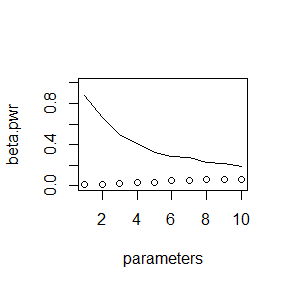

```r
set.seed(123)
sk <- function(x) {
#the sample skewness coeff.
x.mean <- mean(x)
moment.3 <- mean((x - x.mean)^3)
moment.2 <- mean((x - x.mean)^2)
return( moment.3 / moment.2^1.5 )
}


alpha <- 0.1
n <- 30
m <- 2500
parameters <- seq(1,10)
N <- length(parameters)
beta.pwr <- numeric(N)
t.pwr <- numeric(N)
cv <- qnorm(1-alpha/2, 0, sqrt(6*(n-2)/((n+1)*(n+3))))
set.seed(123)


for (j in 1:N) {
  parameter <- parameters[j]
  beta.sktests <- numeric(m)
  t.sktests <- numeric(m)
  for (i in 1:m) {
    x <- rbeta(n, parameter, parameter)
    y <- rt(n, parameter)
    beta.sktests[i] <- as.integer(abs(sk(x))>=cv)
    t.sktests[i] <- as.integer(abs(sk(y))>=cv)
  }
  beta.pwr[j] <- mean(beta.sktests)
  t.pwr[j] <- mean(t.sktests)
}
plot(parameters, beta.pwr, type = 'b', ylim = c(0,1))
lines(parameters, t.pwr)
```

The results are different for heavy-tailed symmetric alternatives.

## Exercise 6.8

Refer to Example 6.16. Repeat the simulation, but also compute the F test of equal variance, at significance $\hat{\alpha}=0.055$.Compare the power of the Count Five test and F test for small, medium, and large sample sizes.

## Answer

```r
set.seed(123)
#count 5 test function
c5t <- function(x, y) {
  x.st <- x - mean(x)
  y.st <- y - mean(y)
  outx <- sum(x.st >  max(y.st)) + sum(x.st < min(y.st))
  outy <- sum(y.st > max(x.st)) + sum(y.st < min(x.st))
  return(as.integer(max(c(outx, outy)) > 5))
}

#F test function
Ft <- function(x, y) {
  Fvalue <- (sd(x)/sd(y))^2
  return(qf(0.055/2, length(x)-1,length(y)-1) > Fvalue|  Fvalue > qf(1-0.055/2,length(x)-1,length(y)-1))
}

m <- c(10, 100, 1000)
for (i in seq(1,3,1)) {
power.c5t <- mean(replicate(1000, expr = {
  x <- rnorm(m[i], 0, 1)
  y <- rnorm(m[i], 0, 1.5)
  c5t(x,y)
}))

power.Ft <- mean(replicate(1000, expr = {
  x <- rnorm(m[i], 0, 1)
  y <- rnorm(m[i], 0, 1.5)
  Ft(x,y)
}))

print(c(power.c5t,power.Ft))
}
```

```
## [1] 0.112 0.187
## [1] 0.866 0.976
## [1] 0.997 1.000
```

## Project 6.C

Repeat Examples 6.8 and 6.10 for Mardia’s multivariate skewness test.

## Answer

```r
set.seed(123)
# mardia test  function
mt.s <- function(x) {
  r <- nrow(x)
  var.inver <- solve(var(x))
  stastic <- sum((x%*%var.inver%*%t(x))^3)/r^2
}

n <- c(10, 20, 30, 50, 100, 500)
p.reject <- numeric(length(n))
m <- 100

for (i in 1:length(n)) {
  mts <- numeric(m)
  for (j in 1:m) {
    x <- as.matrix(rnorm(n[i]))
    mts[j] <- as.integer(abs(mt.s(x)) >= qchisq(0.95,1))
  }
  p.reject[i] <- mean(mts)
}
p.reject
```

```
## [1] 0.06 0.04 0.00 0.00 0.00 0.00
```

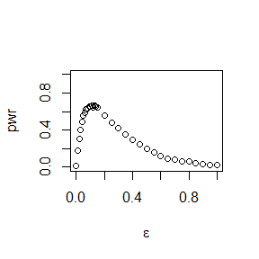

```r
set.seed(123)
mt.s <- function(x) {
  r <- nrow(x)
  var.inver <- solve(var(x))
  stastic <- sum((x%*%var.inver%*%t(x))^3)/r^2
}

alpha <- .1
n <- 30
m <- 2500
epsilon <- c(seq(0, .15, .01), seq(.15, 1, .05))
N <- length(epsilon)
pwr <- numeric(N)
#critical value for the skewness test

for (j in 1:N) { #for each epsilon
  e <- epsilon[j]
  sktests <- numeric(m)
  for (i in 1:m) { #for each replicate
    sigma <- sample(c(1, 10), replace = TRUE,size = n, prob = c(1-e, e))
    x <- matrix(rnorm(n, 0, sigma))
    sktests[i] <- as.integer(mt.s(x) >= qchisq(0.9,1))
  }
  pwr[j] <- mean(sktests)
}
#plot power vs epsilon
plot(epsilon, pwr, type = "b",xlab = bquote(epsilon), ylim = c(0,1))
```

## Discussion

If we obtain the powers for two methods under a particular simulation setting with 10,000 experiments: say, 0.651 for one method and 0.676 for another method. Can we say the powers are different at 0.05 level?  
1.What is the corresponding hypothesis test problem?  
2.What test should we use? Z-test, two-sample t-test, paired-t test or McNemar test?  
3.What information is needed to test your hypothesis?

## Answer

1. $H_0$: the powers are same;$H_1$:the powers are different
2. Paired t test
3. The information of the data in experiments whether reject or accept the null hypothesis.

##Answer

```r
set.seed(1234)
library(bootstrap)
n <- nrow(law)
theta.hat <- cor(law$LSAT, law$GPA)
theta <- numeric(n)
for (i in 1:n) {
  LSAT <- law$LSAT[-i]
  GPA <- law$GPA[-i]
  theta[i] <- cor(LSAT, GPA)
}
theta.bar <- mean(theta)
bias <- (n-1) * (theta.bar - theta.hat)
sde <- (n-1)/(sqrt(n)) * sd(theta)
print(c(bias, sde))
```

```
## [1] -0.006473623  0.142518619
```

## Answer

```r
set.seed(1234)
library(boot)
boot.theta <- function(x,i) mean(x[i])
R <- aircondit$hours
de <- boot(data = R, statistic = boot.theta, R = 999)
ci <- boot.ci(de,type = c('norm','basic','perc','bca'))
ci
```

```
## BOOTSTRAP CONFIDENCE INTERVAL CALCULATIONS
## Based on 999 bootstrap replicates
##
## CALL :
## boot.ci(boot.out = de, type = c("norm", "basic", "perc", "bca"))
##
## Intervals :
## Level      Normal              Basic
## 95%   ( 35.2, 180.9 )   ( 23.7, 169.7 )
##
## Level     Percentile            BCa
## 95%   ( 46.5, 192.5 )   ( 59.0, 229.1 )
## Calculations and Intervals on Original Scale
## Some BCa intervals may be unstable
```

The distribution of the statistics by different methods are different,so intervals are differ.

## Exercise 7.8

Refer to Exercise 7.7. Obtain the jackknife estimates of bias and standard error of $\hat{\theta}$.

## Answer

```r
set.seed(1234)
library(bootstrap)
n <- nrow(scor)
lambda <- eigen(cov(scor))$values
theta <- lambda[1] / sum(lambda)
theta.hat <- numeric(n)

for (i in 1:n) {
  x <- scor[-i,]
  lambda.hat <- eigen(cov(x))$values
  theta.hat[i] <- lambda.hat[1] / sum(lambda.hat)
}

bias <- (n-1) * (mean(theta.hat) - theta)
sde <- (n-1)/(sqrt(n)) * sd(theta.hat)

print(c(bias, sde))
```

```
## [1] 0.001069139 0.049552307
```

## Exercise 7.11

In Example 7.18, leave-one-out(n-fold) cross validation was used to select the best fitting model. Use leave-two-out cross validation to compare the methods.

## Answer

```r
set.seed(1)
library(DAAG)
library(boot)
attach(ironslag)
n <- length(magnetic)
e1 <- e2 <- e3 <- e4 <- numeric((n-1)*n)
number <- 1
for (i in 1:n) {
  for (j in 1:n) {
    if (j != i) {
      y <- magnetic[c(-i,-j)]
      x <- chemical[c(-i,-j)]

      J1 <- lm(y ~ x)
      yhat1 <- J1$coef[1] + J1$coef[2] * chemical[i]
      yhat2 <- J1$coef[1] + J1$coef[2] * chemical[j]
      e1[number] <- magnetic[i] - yhat1
      e1[number + 1] <- magnetic[j] - yhat2

      J2 <- lm(y ~ x + I(x^2))
      yhat1 <- (J2$coef[1] + J2$coef[2] * chemical[i] + J2$coef[3] * chemical[i]^2)
      yhat2 <- (J2$coef[1] + J2$coef[2] * chemical[j] + J2$coef[3] * chemical[j]^2)
      e2[number] <- magnetic[i] - yhat1
      e2[number + 1] <- magnetic[j] - yhat2

      J3 <- lm(log(y) ~ x)
      logyhat1 <- J3$coef[1] + J3$coef[2] * chemical[i]
      yhat1 <- exp(logyhat1)
      logyhat2 <- J3$coef[1] + J3$coef[2] * chemical[j]
      yhat2 <- exp(logyhat2)
      e3[number] <- magnetic[i] - yhat1
      e3[number + 1] <- magnetic[j] - yhat2

      J4 <- lm(log(y) ~ log(x))
      logyhat1 <- J4$coef[1] + J4$coef[2] * log(chemical[i])
      yhat1 <- exp(logyhat1)
      logyhat2 <- J4$coef[1] + J4$coef[2] * log(chemical[j])
      yhat2 <- exp(logyhat2)
      e4[number] <- magnetic[i] - yhat1
      e4[number + 1] <- magnetic[j] - yhat2

      number = number + 1
    }
  }
}

c(mean(e1^2), mean(e2^2), mean(e3^2), mean(e4^2))
```

```
## [1] 19.58136 17.87454 18.46714 20.48373
```

```r
L2 <- lm(magnetic ~ chemical + I(chemical^2))
```

The second model is best.

## Exercise 8.3

The Count 5 test for equal variance in Section 6.4 is based on the maximum number of extreme points. Example 6.15 shows that the Count 5 criterion is not applicable for unequal sample sizes. Implement a permutation test for equal variance based on the maximum number of extreme points that applies when sample sizes are not necessarily equal.

## Answer

```r
set.seed(123)


CFT <- function(x,y) {
  xbar <- x - mean(x)
  ybar <- y - mean(y)
  X.out <- sum(xbar > max(ybar)) + sum(xbar < min(ybar))
  Y.out <- sum(ybar > max(xbar)) + sum(ybar < min(xbar))

  return(as.integer(max(c(X.out, Y.out)) > 5))
}

CFTP <- function(x,y,r) {
  z <- c(x,y)
  output <- numeric(r)
  n <- length(z)
  for (i in 1:r) {
    index <- sample(1:n, n, replace = FALSE)
    index1 <- index[1 : (n/2)]
    index2 <- index[(n/2+1) : n]
    output[i] <- CFT(z[index1], z[index2])
  }
  mean(output)
}

n1 <- 20
n2 <- 50
mean1 <- 0
mean2 <- 0
sigm <- 1
R <- 100

count5test <- mean(replicate(R,expr = {
  x <- rnorm(n1, mean1, sigm)
  y <- rnorm(n2, mean2, sigm)
  CFT(x,y)
}))

count5test.p <- mean(replicate(R, expr = {
  x <- rnorm(n1, mean1, sigm)
  y <- rnorm(n2, mean2, sigm)
  CFTP(x, y, 100)
}) )

print(c(count5test, count5test.p))
```

```
## [1] 0.3000 0.0678
```

## Question

Design experiments for evaluating the performance of the NN,energy, and ball methods in various situations.  
Unequal variances and equal expectations  
Unequal variances and unequal expectations  
Non-normal distributions: t distribution with 1 df, bimodel distribution  
Unbalanced samples

## Answer

```r
library(RANN)
library(boot)
library(energy)
library(Ball)
library(mvtnorm)
set.seed(123)

Tn <- function(z, ix, sizes,k) {
  n1 <- sizes[1]; n2 <- sizes[2]; n <- n1 + n2
  if(is.vector(z)) z <- data.frame(z,0);
  z <- z[ix, ];
  NN <- nn2(data=z, k=k+1) # what's the first column?
  block1 <- NN$nn.idx[1:n1,-1]
  block2 <- NN$nn.idx[(n1+1):n,-1]
  i1 <- sum(block1 < n1 + .5); i2 <- sum(block2 > n1+.5)
  (i1 + i2) / (k * n)
}

m <- 100; k<-3; p<-2; mu <- 0.3;
n1 <- n2 <- 20; R<-999; n <- n1+n2; N = c(n1,n2)
eqdist.nn <- function(z,sizes,k){
  boot.obj <- boot(data=z,statistic=Tn,R=R,
  sim = "permutation", sizes = sizes,k=k)
  ts <- c(boot.obj$t0,boot.obj$t)
  p.value <- mean(ts>=ts[1])
  list(statistic=ts[1],p.value=p.value)
}

p.values <- matrix(NA,m,3)

#Unequal variances and equal expectations
for(i in 1:m){
  x <- rmvnorm(20, mean = c(0,0), sigma = matrix(c(1,0,0,1),ncol = 2))
  y <- rmvnorm(20, mean = c(0,0), sigma = matrix(c(3,0,0,3),ncol = 2))
  z <- rbind(x,y)
  p.values[i,1] <- eqdist.nn(z,N,k)$p.value
  p.values[i,2] <- eqdist.etest(z,sizes=N,R=R)$p.value
  p.values[i,3] <- bd.test(x=x,y=y,num.permutations=999,seed=i*12345)$p.value
}

alpha <- 0.1;
pow <- colMeans(p.values<alpha)

pow
```

```
## [1] 0.43 0.48 0.95
```

```r
#Unequal variances and unequal expectations
for(i in 1:m){
  x <- rmvnorm(20, mean = c(0,0), sigma = matrix(c(1,0,0,1),ncol = 2))
  y <- rmvnorm(20, mean = c(0.6,0.6), sigma = matrix(c(2,0,0,2),ncol = 2))
  z <- rbind(x,y)
  p.values[i,1] <- eqdist.nn(z,N,k)$p.value
  p.values[i,2] <- eqdist.etest(z,sizes=N,R=R)$p.value
  p.values[i,3] <- bd.test(x=x,y=y,num.permutations=999,seed=i*12345)$p.value
}

alpha <- 0.1;
pow <- colMeans(p.values<alpha)

pow
```

```
## [1] 0.49 0.69 0.76
```

```r
#t distribution with 1 df and bimodel distribution
for(i in 1:m){
  x <- rmvt(20, sigma = diag(2), df = 1)
  y1 <- rt(20,3); y2 <- rt(20,5); y <- cbind(y1, y2)
  z <- rbind(x,y)
  p.values[i,1] <- eqdist.nn(z,N,k)$p.value
  p.values[i,2] <- eqdist.etest(z,sizes=N,R=R)$p.value
  p.values[i,3] <- bd.test(x=x,y=y,num.permutations=999,seed=i*12345)$p.value
}

alpha <- 0.1;
pow <- colMeans(p.values<alpha)

pow
```

```
## [1] 0.14 0.39 0.32
```

```r
#Unbalanced samples
for(i in 1:m){
  x <- rmvnorm(30, mean = c(0,0), sigma = matrix(c(1,0,0,1),ncol = 2))
  y <- rmvnorm(10, mean = c(1,1), sigma = matrix(c(2,0,0,2),ncol = 2))
  z <- rbind(x,y)
  p.values[i,1] <- eqdist.nn(z,N,k)$p.value
  p.values[i,2] <- eqdist.etest(z,sizes=N,R=R)$p.value
  p.values[i,3] <- bd.test(x=x,y=y,num.permutations=999,seed=i*12345)$p.value
}

alpha <- 0.1;
pow <- colMeans(p.values<alpha)

pow
```

```
## [1] 0.20 0.50 0.86
```

## Exercise 9.4

Implement a random walk Metropolis sampler for generating the standard Laplace distribution. For the increment, simulate from a normal distribution. Compare the chains generated variances are used for the proposal distribution. Also, compute the acceptance rates of each chain.

The standard Laplace distribution has density $f(x) = \frac{1}{2}e^{-|x|}$

## Answer

```r
set.seed(1)


Lf <- function(x) {
  exp(-abs(x))
}

rwm <- function(sigma) {
  x <- numeric(2000)
  x[1] <- 25
  u <- runif(2000)
  k <- 0
  for (i in 2:2000) {
    y <- rnorm(1, x[i-1], sigma)
    if (u[i] <= (Lf(y) / Lf(x[i-1]))) x[i] = y
    else {
      x[i] = x[i-1]
      k = k + 1
    }
  }
  list(x = x, k = k)
}

sigma <- c(0.05, 0.5, 2, 16)
rw1 <- rwm(sigma[1])
rw2 <- rwm(sigma[2])
rw3 <- rwm(sigma[3])
rw4 <- rwm(sigma[4])

#number of candidate points rejected
    ac.rate <- data.frame(sigma=sigma,no.reject=c((2000-rw1$k)/2000, (2000-rw2$k)/2000, (2000-rw3$k)/2000, (2000-rw4$k)/2000))

    rw <- cbind(rw1$x, rw2$x, rw3$x,  rw4$x)
```

[output not shown]

## Question

For Exercise, use the Gelman-Rubin method to monitor convergence of the chain, and run the chain until it converges approximately to the target distribution to $\hat{R} < 1.2$.

## Answer

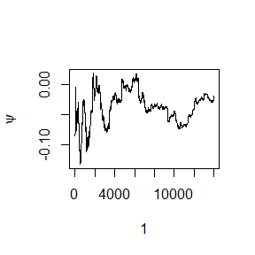

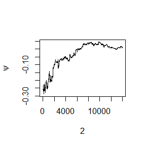

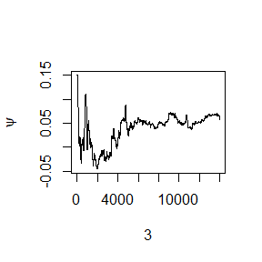

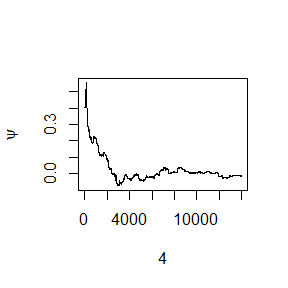

```r
    Lf <- function(x) {
       exp(-abs(x))
      }
    Gelman.Rubin <- function(psi) {
        # psi[i,j] is the statistic psi(X[i,1:j])
        # for chain in i-th row of X
        psi <- as.matrix(psi)
        n <- ncol(psi)
        k <- nrow(psi)

        psi.means <- rowMeans(psi)     #row means
        B <- n * var(psi.means)        #between variance est.
        psi.w <- apply(psi, 1, "var")  #within variances
        W <- mean(psi.w)               #within est.
        v.hat <- W*(n-1)/n + (B/n)     #upper variance est.
        r.hat <- v.hat / W             #G-R statistic
        return(r.hat)
        }

    normal.chain <- function(sigma, N, X1) {
        #generates a Metropolis chain for Normal(0,1)
        #with Normal(X[t], sigma) proposal distribution
        #and starting value X1
        x <- rep(0, N)
        x[1] <- X1
        u <- runif(N)

        for (i in 2:N) {
            xt <- x[i-1]
            y <- rnorm(1, xt, sigma)     #candidate point
            r1 <- Lf(y) * dnorm(xt, y, sigma)
            r2 <- Lf(xt) * dnorm(y, xt, sigma)
            r <- r1 / r2
            if (u[i] <= r) x[i] <- y else
                 x[i] <- xt
            }
        return(x)
        }

    sigma <- 1     #parameter of proposal distribution
    k <- 4          #number of chains to generate
    n <- 15000      #length of chains
    b <- 1000       #burn-in length

    #choose overdispersed initial values
    x0 <- c(-10, -5, 5, 10)

    #generate the chains
    set.seed(12345)
    X <- matrix(0, nrow=k, ncol=n)
    for (i in 1:k)
        X[i, ] <- normal.chain(sigma, n, x0[i])

    #compute diagnostic statistics
    psi <- t(apply(X, 1, cumsum))
    for (i in 1:nrow(psi))
        psi[i,] <- psi[i,] / (1:ncol(psi))

    #plot psi for the four chains

    for (i in 1:k)
        plot(psi[i, (b+1):n], type="l",
            xlab=i, ylab=bquote(psi))
```

```r
    rhat <- rep(0, n)
    for (j in (b+1):n)
        rhat[j] <- Gelman.Rubin(psi[,1:j])
```

[output not shown]

## Exercises 11.4

Find the intersection points A(k) in (0,$\sqrt{k}$) of the curves
$$S_{k-1}(a) = P(t(k-1)>\sqrt{\frac{a^2(k-1)}{k-a^2}})$$
and
$$S_k(a) = P(t(k)>\sqrt{\frac{a^2k}{k+1-a^2}})$$
for k = 4:25,100,500,1000.

## AnswerS

```r
set.seed(1)
S <- function(a,k) {
  constant = sqrt((a^2)*k/(k+1-a^2))
  pt(constant, df = k)
}

root <- function(k) {
  x <- uniroot(function(a){(S(a,k)-S(a,k-1))}, c(0.05,sqrt(k)-0.05))
  x$root
}

x <- c(4:25,100,500,1000)
y <- numeric(25)
for (i in 4:25) {
  y[i-3] <- root(i)
}
y[23] <- root(100)
y[24] <- root(500)
y[25] <- root(1000)

data.frame(degree = x, intersection = y)
```

```
##    degree intersection
## 1       4     1.492103
## 2       5     1.533557
## 3       6     1.562738
## 4       7     1.584428
## 5       8     1.601181
## 6       9     1.614495
## 7      10     1.625360
## 8      11     1.634426
## 9      12     1.642027
## 10     13     1.648530
## 11     14     1.654174
## 12     15     1.659099
## 13     16     1.663445
## 14     17     1.667270
## 15     18     1.670725
## 16     19     1.673817
## 17     20     1.676613
## 18     21     1.679132
## 19     22     1.681447
## 20     23     1.683619
## 21     24     1.685541
## 22     25     4.950000
## 23    100     9.950000
## 24    500    22.310680
## 25   1000    31.572777
```

## Question

A-B-O blood type problem.

## Solution

```r
set.seed(1)
library(nloptr)
nA <- 444
nB <- 132
nOO <- 361
nAB <- 63
f <- function(x, y) {
  r1 <- 1-sum(y)
  nAA <- nA*y[1]^2/(y[1]^2+2*y[1]*r1)
  nBB <- nB*y[2]^2/(y[2]^2+2*y[2]*r1)
  r <- 1-sum(x)
  return(-2*nAA*log(x[1])-2*nBB*log(x[2])-2*nOO*log(r)-(nA-nAA)*log(2*x[1]*r)-(nB-nBB)*log(2*x[2]*r)-nAB*log(2*x[1]*x[2]))
}

g <- function(x,y) {
  return(sum(x)-0.999999)
}

opts <- list("algorithm"="NLOPT_LN_COBYLA",
             "xtol_rel"=1.0e-8)
mle <- NULL
r <- rbind(matrix(0,1,2),c(0.5,0.5))
i <- 2
while (sum(abs(r[i,] - r[i-1,])) > 1e-6) {
      res <- nloptr( x0=c(0.2,0.2),eval_f=f,lb = c(0,0), ub = c(1,1), eval_g_ineq = g, opts = opts, y=r[i,] )
      i <- i+1
      r <- rbind(r,res$solution)
      mle <- c(mle,f(x=r[i,],y=r[i-1,]))
}

#the result of EM algorithm
r
```

```
##            [,1]      [,2]
##  [1,] 0.0000000 0.0000000
##  [2,] 0.5000000 0.5000000
##  [3,] 0.4755000 0.1635000
##  [4,] 0.3416511 0.1096863
##  [5,] 0.3062087 0.1034977
##  [6,] 0.2992214 0.1028196
##  [7,] 0.2979287 0.1027251
##  [8,] 0.2976930 0.1027096
##  [9,] 0.2976502 0.1027069
## [10,] 0.2976424 0.1027064
## [11,] 0.2976410 0.1027063
## [12,] 0.2976407 0.1027063
```

```r
#the max likelihood values
mle
```

```
##  [1] 1991.102 1573.555 1455.089 1432.665 1428.611 1427.878 1427.745 1427.721
##  [9] 1427.717 1427.716
```

## Question

Use both for loops and lapply() to fit linear models to the mtcars.

## Solution

```r
set.seed(1)
attach(mtcars)

formulas <- list(
  mpg ~ disp,
  mpg ~ I(1 / disp),
  mpg ~ disp + wt,
  mpg ~ I(1 / disp) + wt
)

# lapply

lapply(formulas, function(x) lm(x, mtcars))
```

```
## [[1]]
##
## Call:
## lm(formula = x, data = mtcars)
##
## Coefficients:
## (Intercept)         disp
##    29.59985     -0.04122
##
##
## [[2]]
##
## Call:
## lm(formula = x, data = mtcars)
##
## Coefficients:
## (Intercept)    I(1/disp)
##       10.75      1557.67
##
##
## [[3]]
##
## Call:
## lm(formula = x, data = mtcars)
##
## Coefficients:
## (Intercept)         disp           wt
##    34.96055     -0.01772     -3.35083
##
##
## [[4]]
##
## Call:
## lm(formula = x, data = mtcars)
##
## Coefficients:
## (Intercept)    I(1/disp)           wt
##      19.024     1142.560       -1.798
```

```r
# loops

out <- vector("list", length(formulas))
for (i in seq_along(formulas)) {
  out[[i]] <- lm(formulas[[i]], mtcars)
}

out
```

```
## [[1]]
##
## Call:
## lm(formula = formulas[[i]], data = mtcars)
##
## Coefficients:
## (Intercept)         disp
##    29.59985     -0.04122
##
##
## [[2]]
##
## Call:
## lm(formula = formulas[[i]], data = mtcars)
##
## Coefficients:
## (Intercept)    I(1/disp)
##       10.75      1557.67
##
##
## [[3]]
##
## Call:
## lm(formula = formulas[[i]], data = mtcars)
##
## Coefficients:
## (Intercept)         disp           wt
##    34.96055     -0.01772     -3.35083
##
##
## [[4]]
##
## Call:
## lm(formula = formulas[[i]], data = mtcars)
##
## Coefficients:
## (Intercept)    I(1/disp)           wt
##      19.024     1142.560       -1.798
```

## Question

The following code simulates the performance of a t-test for non-normal data. Use sapply() and an anonymous function to extract the p-value from trial.

## Solution

```r
set.seed(1)
trials <- replicate(
  100,
  t.test(rpois(10,10), rpois(7,10)),
  simplify = FALSE
)

sapply(trials,  function(x) x[["p.value"]])
```

```
##   [1] 0.125949930 0.800930340 0.952855296 0.452959855 0.483083494 0.320611150
##   [7] 0.706780317 0.063119508 0.621092522 0.162276154 0.820427933 0.053095862
##  [13] 0.914712292 0.792200487 0.390189150 0.538640844 0.143988430 0.788393427
##  [19] 0.672267752 0.216269737 0.534646674 0.809214595 0.960266963 0.569466705
##  [25] 0.632178255 0.582700745 0.254983356 0.282179271 0.005098396 0.162075913
##  [31] 0.877783340 0.654074362 0.169752059 0.754440969 0.764179721 0.026793925
##  [37] 0.114713268 0.028496672 0.598991648 0.885239097 0.719211331 0.409696973
##  [43] 0.847167535 0.764438221 0.418863595 0.519132187 0.463910875 0.286785195
##  [49] 0.875030871 0.241068098 0.838739962 0.348638336 0.622633185 0.232606824
##  [55] 0.398974335 0.970218660 0.860375193 0.909101881 0.851096482 0.523397015
##  [61] 0.746860279 0.764894312 0.025411594 0.019036587 0.397989350 0.714919878
##  [67] 0.631471636 0.110724341 0.927143289 0.041990454 0.208117904 0.607178718
##  [73] 0.906974079 0.554576397 0.194404278 0.771678543 0.396686801 0.803958799
##  [79] 0.768941702 0.994186553 0.194123673 0.316046848 0.415575715 0.619270683
##  [85] 0.295629509 0.942948679 0.607585865 0.718018866 0.761453123 0.120281420
##  [91] 0.577128336 0.019315507 0.483007741 0.108496205 0.469918314 0.011282410
##  [97] 0.231024499 0.955230239 0.964944823 0.281065452
```

## Question

Implement a combination of Map() and vapply() to create an lapply() variant that iterates in parallel over all of its inputs and stores its outputs in a vector (or a matrix). What arguments should the function take?

## Exercise

```r
set.seed(1)
attach(mtcars)
#lapply()
lapply(mtcars, is.numeric)
```

```
## $mpg
## [1] TRUE
##
## $cyl
## [1] TRUE
##
## $disp
## [1] TRUE
##
## $hp
## [1] TRUE
##
## $drat
## [1] TRUE
##
## $wt
## [1] TRUE
##
## $qsec
## [1] TRUE
##
## $vs
## [1] TRUE
##
## $am
## [1] TRUE
##
## $gear
## [1] TRUE
##
## $carb
## [1] TRUE
```

```r
#vapply() + Map()
f <- function(x) {x}
Map(f,vapply(mtcars, is.numeric, logical(1)))
```

```
## $mpg
## [1] TRUE
##
## $cyl
## [1] TRUE
##
## $disp
## [1] TRUE
##
## $hp
## [1] TRUE
##
## $drat
## [1] TRUE
##
## $wt
## [1] TRUE
##
## $qsec
## [1] TRUE
##
## $vs
## [1] TRUE
##
## $am
## [1] TRUE
##
## $gear
## [1] TRUE
##
## $carb
## [1] TRUE
```

## Question

Write an Rcpp function for Exercise 9.4 (page 277, Statistical Computing with R).  
1. Compare the corresponding generated random numbers with those by the R function you wrote before using the function “qqplot”.  
2. Campare the computation time of the two functions with the function “microbenchmark”.  
3. Comments your results.

```r
library(Rcpp)
library(microbenchmark)
```

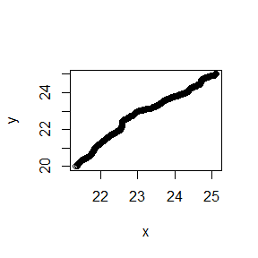

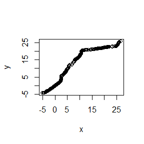

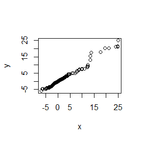

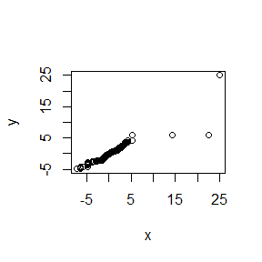

```r
# R function
lap_f = function(x) exp(-abs(x))

rw.Metropolis = function(sigma, x0, N){
 x = numeric(N)
 x[1] = x0
 u = runif(N)
 k = 0
 for (i in 2:N) {
  y = rnorm(1, x[i-1], sigma)
  if (u[i] <= (lap_f(y) / lap_f(x[i-1]))) x[i] = y
  else {
  x[i] = x[i-1]
  k = k+1
  }
 }
 return(list(x = x, k = k))
}

# Cpp function

cppFunction('NumericVector rwMCpp(double sigma,double x0,int N) {
  NumericVector x(N);
  x[0]=x0;
  NumericVector u(N);
  u=runif(N);
  for(int i=1;i<N;i++){
    NumericVector y(1);
    y=rnorm(1, x[i-1], sigma);
    if(u[i] <= ((exp(-abs(y[0]))) / (exp(-abs(x[i-1]))))){
      x[i] = y[0];
    }
    else{
      x[i] = x[i-1];
    }
  }
  return x;
}')


# Compare by qqplot
N = 2000
sigma = c(.05, .5, 2, 16)
x0 = 25
for (i in 1:length(sigma)) {
    x = rw.Metropolis(sigma[i],x0,N)$x
    y = rwMCpp(sigma[i],x0,N)
    qqplot(x,y)
}
```

```r
# compare the time

for (i in 1:length(sigma)) {
  time <- microbenchmark(rw.Metropolis(sigma[i],x0,N),rwMCpp(sigma[i],x0,N))
  print(summary(time)[,c(1,3,5,6)])
}
```

```
##                             expr     lq  median      uq
## 1 rw.Metropolis(sigma[i], x0, N) 6098.8 6171.95 6384.35
## 2        rwMCpp(sigma[i], x0, N)  421.6  426.60  432.90
##                             expr      lq median      uq
## 1 rw.Metropolis(sigma[i], x0, N) 6126.60 6203.4 6379.45
## 2        rwMCpp(sigma[i], x0, N)  460.85  465.5  471.15
##                             expr      lq  median      uq
## 1 rw.Metropolis(sigma[i], x0, N) 6188.45 6251.60 6494.45
## 2        rwMCpp(sigma[i], x0, N)  462.25  467.15  477.10
##                             expr     lq median      uq
## 1 rw.Metropolis(sigma[i], x0, N) 6189.0 6248.3 6367.30
## 2        rwMCpp(sigma[i], x0, N)  444.9  452.2  459.15
```

The results are similar with two different functions, and Cpp function is faster.